# Week 1: DecisionTreeClassifier

## Importing modules and data

```python
import pandas as pd
import seaborn as sns
import numpy as np
import matplotlib.pyplot as plt
import random

from sklearn.preprocessing import StandardScaler
from sklearn.model_selection import train_test_split
from sklearn.metrics import accuracy_score, confusion_matrix
from sklearn.tree import DecisionTreeClassifier
from sklearn.model_selection import GridSearchCV
from sklearn.metrics import plot_confusion_matrix, f1_score
```

```python
train_data = pd.read_csv("train.csv")
test_data = pd.read_csv("test.csv")
```

## Exploring the data

```python
train_data.head().transpose()
```

|  | 0 | 1 | 2 | 3 | 4 |
| --- | --- | --- | --- | --- | --- |
| id | 6.265700e+04 | 1.964370e+05 | 1.596600e+05 | 2.277770e+05 | 2.213360e+05 |
| M1 | -9.013900e+02 | -2.738880e+03 | -6.344000e+01 | -2.755910e+03 | 4.174800e+02 |
| M2 | 3.662000e+03 | -6.035500e+02 | 8.811000e+02 | -9.896900e+02 | -4.000000e+02 |
| M3 | 3.177000e+03 | 9.503000e+02 | 2.715940e+03 | 3.574320e+03 | 8.899000e+02 |
| mL1 | 1.570260e+03 | 8.778200e+02 | 2.074920e+03 | 2.156450e+03 | 2.005440e+03 |
| mL3 | 1.033470e+03 | 9.816300e+02 | 1.778560e+03 | 3.622040e+03 | 1.545480e+03 |
| me1 | 3.250000e+03 | 1.321130e+03 | 1.649110e+03 | 2.417060e+03 | 8.691600e+02 |
| me3 | 3.004430e+03 | 1.328460e+03 | 3.184100e+03 | 3.165180e+03 | 1.179770e+03 |
| mQ1 | 2.090140e+03 | 3.497340e+03 | 2.378100e+03 | 3.444000e+03 | 7.328800e+02 |
| mQt | 3.648440e+03 | 2.799690e+03 | 1.798380e+03 | 2.938060e+03 | 1.048780e+03 |
| mu1 | 3.958750e+03 | 1.467760e+03 | 3.417940e+03 | 1.743940e+03 | 3.368460e+03 |
| mu3 | 2.088780e+03 | 3.634870e+03 | 3.963750e+03 | 2.271620e+03 | 2.390490e+03 |
| md1 | 2.366050e+03 | 9.854100e+02 | 3.373970e+03 | 1.698280e+03 | 3.155920e+03 |
| md3 | 1.412200e+03 | 2.440580e+03 | 3.981510e+03 | 1.260140e+03 | 1.458440e+03 |
| At | -3.388989e+03 | -3.992969e+03 | -3.490759e+03 | 2.543820e+03 | -4.410110e+03 |
| Ab | -2.522809e+03 | 1.100600e+02 | 3.119840e+03 | 3.503200e+02 | 1.416080e+03 |
| Atau | 3.619120e+03 | 3.263620e+03 | -1.152050e+03 | 2.025180e+03 | -2.611150e+03 |
| mu | 3.642493e+02 | 6.162311e+02 | 1.541792e+02 | 5.343544e+02 | 9.268594e+02 |
| mA2 | 2.553254e+06 | 9.554702e+06 | 6.029291e+06 | 3.640130e+06 | 5.952400e+06 |
| tanbeta | 5.517943e+01 | 6.513831e+00 | 4.190568e+01 | 2.398326e+01 | 6.111299e+00 |
| truth_8tev | 1.000000e+00 | 0.000000e+00 | 1.000000e+00 | 1.000000e+00 | 0.000000e+00 |

```python
test_data.head().transpose()
```

|  | 0 | 1 | 2 | 3 | 4 |
| --- | --- | --- | --- | --- | --- |
| id | 4.477200e+04 | 2.715810e+05 | 5.267300e+04 | 2.932300e+04 | 1.353430e+05 |
| M1 | -3.265600e+02 | 1.967600e+03 | -5.949800e+02 | 2.883200e+02 | -3.798450e+03 |
| M2 | 2.254510e+03 | -4.955900e+02 | -3.175560e+03 | 2.744600e+02 | 6.973300e+02 |
| M3 | 3.092040e+03 | 2.763240e+03 | 1.869730e+03 | 2.627770e+03 | 2.627920e+03 |
| mL1 | 5.005800e+02 | 3.809200e+03 | 3.379230e+03 | 1.749280e+03 | 3.825390e+03 |
| mL3 | 8.394800e+02 | 2.025780e+03 | 1.511560e+03 | 1.511440e+03 | 2.545400e+03 |
| me1 | 3.357820e+03 | 3.626990e+03 | 7.056400e+02 | 3.914380e+03 | 1.380110e+03 |
| me3 | 2.122670e+03 | 2.682610e+03 | 3.828390e+03 | 2.432710e+03 | 9.351200e+02 |
| mQ1 | 1.503340e+03 | 1.449290e+03 | 7.020300e+02 | 6.902100e+02 | 2.768320e+03 |
| mQt | 1.400890e+03 | 2.348400e+03 | 4.295500e+02 | 1.435750e+03 | 2.238720e+03 |
| mu1 | 1.798640e+03 | 2.422110e+03 | 1.699720e+03 | 2.714570e+03 | 1.483650e+03 |
| mu3 | 3.433620e+03 | 3.553590e+03 | 3.722980e+03 | 3.647570e+03 | 1.239710e+03 |
| md1 | 3.679240e+03 | 1.046950e+03 | 2.564630e+03 | 1.772100e+03 | 9.210300e+02 |
| md3 | 7.797200e+02 | 2.661440e+03 | 2.162970e+03 | 3.029370e+03 | 8.303300e+02 |
| At | 3.399890e+03 | -2.737359e+03 | -5.814820e+03 | -2.897129e+03 | -3.870729e+03 |
| Ab | 1.693140e+03 | 3.690820e+03 | -3.662060e+03 | 8.095700e+02 | -3.583850e+03 |
| Atau | 3.534700e+03 | -2.821079e+03 | 2.596020e+03 | 1.544740e+03 | 2.535960e+03 |
| mu | -3.343138e+02 | -2.284882e+03 | 7.371301e+02 | -1.342227e+03 | 1.207915e+03 |
| mA2 | 6.445286e+06 | 1.391392e+07 | 1.591708e+07 | 7.066069e+06 | 1.356937e+07 |
| tanbeta | 2.472194e+01 | 4.292162e+01 | 9.994744e+00 | 1.577691e+01 | 5.853051e+00 |

```python
train_data.isna().sum().sum()
```

```
0
```

```python
train_data.columns
```

```
Index(['id', 'M1', 'M2', 'M3', 'mL1', 'mL3', 'me1', 'me3', 'mQ1', 'mQt', 'mu1',
       'mu3', 'md1', 'md3', 'At', 'Ab', 'Atau', 'mu', 'mA2', 'tanbeta',
       'truth_8tev'],
      dtype='object')
```

```python
train_data.shape
```

```
(300324, 21)
```

```python
test_data.columns
```

```
Index(['id', 'M1', 'M2', 'M3', 'mL1', 'mL3', 'me1', 'me3', 'mQ1', 'mQt', 'mu1',
       'mu3', 'md1', 'md3', 'At', 'Ab', 'Atau', 'mu', 'mA2', 'tanbeta'],
      dtype='object')
```

```python
test_data.shape
```

```
(10000, 20)
```

```python
train_data.describe()
```

|  | id | M1 | M2 | M3 | mL1 | mL3 | me1 | me3 | mQ1 | mQt | ... | mu3 | md1 | md3 | At | Ab | Atau | mu | mA2 | tanbeta | truth_8tev |
| --- | --- | --- | --- | --- | --- | --- | --- | --- | --- | --- | --- | --- | --- | --- | --- | --- | --- | --- | --- | --- | --- |
| count | 300324.000000 | 300324.000000 | 300324.000000 | 300324.000000 | 300324.000000 | 300324.000000 | 300324.000000 | 300324.000000 | 300324.000000 | 300324.000000 | ... | 300324.000000 | 300324.000000 | 300324.000000 | 300324.000000 | 300324.000000 | 300324.000000 | 300324.000000 | 3.003240e+05 | 300324.000000 | 300324.000000 |
| mean | 155179.859592 | 3.386331 | 5.524361 | 2177.089317 | 2215.423856 | 2220.043932 | 2192.472315 | 2229.793033 | 2197.093690 | 2589.846939 | ... | 2795.519332 | 2127.021615 | 2187.672937 | -561.616330 | 4.702701 | 0.761455 | 270.983033 | 7.288482e+06 | 25.397719 | 0.592410 |
| std | 89586.623380 | 2021.607166 | 2056.764829 | 1051.828618 | 1040.685785 | 1038.435035 | 1052.295581 | 1032.425886 | 1054.162076 | 924.466887 | ... | 840.687390 | 1079.123094 | 1071.109825 | 3669.112164 | 2292.731054 | 2283.660775 | 1587.449940 | 4.648794e+06 | 14.825419 | 0.491387 |
| min | 0.000000 | -3999.990000 | -4000.000000 | 200.000000 | 90.879999 | 91.419997 | 90.020000 | 90.250001 | 200.029990 | 111.460000 | ... | 264.019990 | 200.019900 | 100.069940 | -7998.919000 | -3999.970000 | -3999.970000 | -4381.715000 | 1.364555e+03 | 2.672445 | 0.000000 |
| 25% | 77553.750000 | -1344.410000 | -1460.862500 | 1310.070000 | 1344.280000 | 1351.667500 | 1312.680000 | 1364.477500 | 1314.159900 | 1878.587425 | ... | 2201.439975 | 1201.589900 | 1289.699975 | -3678.479250 | -1971.527250 | -1960.460000 | -459.050325 | 3.168507e+06 | 12.854422 | 0.000000 |
| 50% | 155218.500000 | 43.090000 | 98.730000 | 2204.680000 | 2228.680000 | 2233.005000 | 2204.220000 | 2242.530000 | 2208.304900 | 2695.809900 | ... | 2930.169900 | 2121.844950 | 2214.589950 | -2683.979000 | 3.680004 | 2.270002 | 206.436755 | 6.776729e+06 | 22.951727 | 1.000000 |
| 75% | 232745.500000 | 1356.190000 | 1478.772500 | 3064.787500 | 3110.705000 | 3114.770000 | 3096.560000 | 3118.847500 | 3107.254975 | 3381.682400 | ... | 3505.830000 | 3057.877400 | 3111.892475 | 3209.462500 | 1982.872500 | 1964.460000 | 983.402645 | 1.113073e+07 | 36.125405 | 1.000000 |
| max | 310323.000000 | 3999.950000 | 3999.830000 | 3999.980000 | 4000.000000 | 3999.980000 | 3999.990000 | 4000.000000 | 3999.989900 | 3999.999900 | ... | 3999.980000 | 3999.970000 | 4000.000000 | 7993.830000 | 3999.950000 | 3999.940000 | 4132.479300 | 3.756981e+07 | 66.371989 | 1.000000 |

8 rows × 21 columns

In the description of the training data, we can see that roughly 60% of the data are labeled 'positive' (1.0).

```python
test_data.describe()
```

|  | id | M1 | M2 | M3 | mL1 | mL3 | me1 | me3 | mQ1 | mQt | mu1 | mu3 | md1 | md3 | At | Ab | Atau | mu | mA2 | tanbeta |
| --- | --- | --- | --- | --- | --- | --- | --- | --- | --- | --- | --- | --- | --- | --- | --- | --- | --- | --- | --- | --- |
| count | 10000.000000 | 10000.000000 | 10000.000000 | 10000.000000 | 10000.000000 | 10000.000000 | 10000.000000 | 10000.000000 | 10000.000000 | 10000.000000 | 10000.000000 | 10000.000000 | 10000.000000 | 10000.000000 | 10000.000000 | 10000.000000 | 10000.000000 | 10000.000000 | 1.000000e+04 | 10000.000000 |
| mean | 154610.117400 | 13.430401 | -0.051408 | 2182.699293 | 2214.825431 | 2227.622078 | 2178.889166 | 2232.666613 | 2194.323175 | 2578.761136 | 2136.245003 | 2799.853750 | 2122.248312 | 2185.752148 | -624.572731 | -8.741997 | 44.046377 | 296.320126 | 7.237227e+06 | 25.306870 |
| std | 89475.800192 | 2001.378388 | 2054.212498 | 1053.786163 | 1030.743574 | 1038.200271 | 1058.910248 | 1033.297348 | 1055.419685 | 921.517730 | 1077.245885 | 841.620335 | 1076.146059 | 1071.562726 | 3655.420801 | 2288.307251 | 2298.147053 | 1594.139276 | 4.634870e+06 | 14.769207 |
| min | 1.000000 | -3999.040000 | -3999.750000 | 200.670000 | 101.870000 | 115.880000 | 94.699999 | 91.419991 | 201.069960 | 102.650000 | 200.089950 | 310.469990 | 200.159970 | 102.289560 | -7982.889000 | -3998.590000 | -3999.280000 | -4117.013000 | 2.212208e+03 | 2.809727 |
| 25% | 78282.250000 | -1280.857500 | -1502.570000 | 1313.552500 | 1366.160000 | 1356.655000 | 1298.372500 | 1368.162500 | 1299.569900 | 1868.102475 | 1206.442400 | 2204.744975 | 1209.904900 | 1274.879900 | -3685.936500 | -1974.246750 | -1960.495000 | -450.779100 | 3.149597e+06 | 12.851731 |
| 50% | 153825.000000 | 53.375000 | 96.660000 | 2213.900000 | 2231.555000 | 2247.235000 | 2180.535000 | 2246.855000 | 2202.474950 | 2669.904900 | 2138.024950 | 2950.089950 | 2111.324900 | 2207.514950 | -2718.675000 | 29.070006 | 79.595000 | 214.315820 | 6.708734e+06 | 22.826773 |
| 75% | 232679.250000 | 1321.345000 | 1472.897500 | 3070.817500 | 3102.832500 | 3124.862500 | 3092.915000 | 3112.392500 | 3100.449975 | 3367.869900 | 3065.257425 | 3506.197425 | 3045.337500 | 3116.622425 | 3191.272500 | 1949.435000 | 2036.032500 | 1021.241000 | 1.105563e+07 | 35.907607 |
| max | 310298.000000 | 3998.720000 | 3998.490000 | 3998.400000 | 3999.800000 | 3999.930000 | 3999.900000 | 3999.900000 | 3999.900000 | 3999.580000 | 3999.850000 | 3999.999900 | 3999.740000 | 3999.810000 | 7786.960000 | 3999.250000 | 3999.150000 | 4076.604400 | 2.560442e+07 | 62.326404 |

## Creating the labels for training

```python
features = train_data.keys()[1:-1]
targets = train_data.keys()[-1]
print(f"Features: {[x for x in features]} \n")
print(f"Target: {targets}")
```

```
Features: ['M1', 'M2', 'M3', 'mL1', 'mL3', 'me1', 'me3', 'mQ1', 'mQt', 'mu1', 'mu3', 'md1', 'md3', 'At', 'Ab', 'Atau', 'mu', 'mA2', 'tanbeta']

Target: truth_8tev
```

## Mean and variance of train vs test set

```python
pd.DataFrame((train_data[features].mean() - test_data[features].mean(), (train_data[features].std() - test_data[features].std())), index=("Mean diff", "std diff")).transpose()
```

|  | Mean diff | std diff |
| --- | --- | --- |
| M1 | -10.044070 | 20.228778 |
| M2 | 5.575769 | 2.552331 |
| M3 | -5.609976 | -1.957544 |
| mL1 | 0.598425 | 9.942211 |
| mL3 | -7.578146 | 0.234764 |
| me1 | 13.583149 | -6.614667 |
| me3 | -2.873580 | -0.871462 |
| mQ1 | 2.770516 | -1.257610 |
| mQt | 11.085803 | 2.949156 |
| mu1 | 0.691150 | -0.628098 |
| mu3 | -4.334418 | -0.932945 |
| md1 | 4.773303 | 2.977036 |
| md3 | 1.920789 | -0.452902 |
| At | 62.956401 | 13.691363 |
| Ab | 13.444698 | 4.423802 |
| Atau | -43.284922 | -14.486277 |
| mu | -25.337094 | -6.689335 |
| mA2 | 51255.139433 | 13923.697922 |
| tanbeta | 0.090849 | 0.056211 |

This exploration of the data was taken from the Demo script provided by the course. It seems that some parameters have different ranges and therefore can cause some problems for the model (since it can make the assumption that greater values are more important than lesser values). It would be wise to apply normalization.

# Visualization

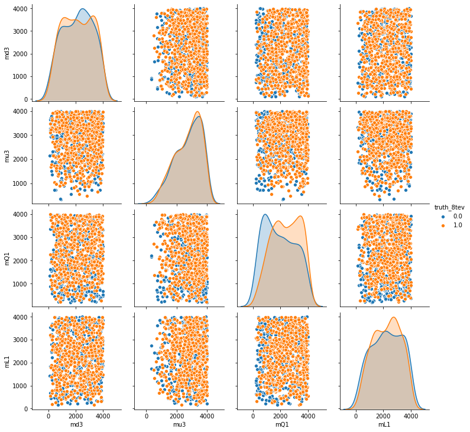

```python
sns.pairplot(train_data.iloc[0:1000], hue='truth_8tev', vars=[random.choice(features) for _ in range(4)])
```

I added some randomization for the choice of features, but without checking if the feature is already present. I suppose it wouldnt be that hard to do this, but since this is not of vital importance right now I will leave it as such.

Looking at the distributions, it is interesting to see that quite a few features have great overlap regarding the target categories. However, there also seem to be some features that might do a better job.

# Normalization

We dont calculate a different mean and standard deviation (std) for the test data. This would be inefficient, since the model we are going to train will be trained on the mean and std of the training data.

```python
# copy data
train_norm, test_norm = train_data.copy(), test_data.copy()

# calculate mean and standard deviation
mean = train_norm[features].mean()
std = train_norm[features].std(ddof=0)

# calculate new values
train_norm[features] = (train_norm[features] - mean)/std
test_norm[features] = (test_norm[features] - mean)/std

# Save results
train_norm.to_csv('train_zscore.csv')
test_norm.to_csv('test_zscore.csv')
mean.to_csv('zscore_mean.csv', header=False)
std.to_csv('zscore_std.csv', header=False)

#Verify results
train_norm.describe()
```

|  | id | M1 | M2 | M3 | mL1 | mL3 | me1 | me3 | mQ1 | mQt | ... | mu3 | md1 | md3 | At | Ab | Atau | mu | mA2 | tanbeta | truth_8tev |
| --- | --- | --- | --- | --- | --- | --- | --- | --- | --- | --- | --- | --- | --- | --- | --- | --- | --- | --- | --- | --- | --- |
| count | 300324.000000 | 3.003240e+05 | 3.003240e+05 | 3.003240e+05 | 3.003240e+05 | 3.003240e+05 | 3.003240e+05 | 3.003240e+05 | 3.003240e+05 | 3.003240e+05 | ... | 3.003240e+05 | 3.003240e+05 | 3.003240e+05 | 3.003240e+05 | 3.003240e+05 | 3.003240e+05 | 3.003240e+05 | 3.003240e+05 | 3.003240e+05 | 300324.000000 |
| mean | 155179.859592 | -3.318943e-18 | 1.183099e-17 | 6.086632e-14 | -1.583031e-14 | -1.313027e-14 | -7.177688e-15 | 2.662267e-14 | 1.578319e-13 | 4.560090e-13 | ... | 5.175687e-13 | 8.960049e-14 | 1.213945e-13 | -1.620904e-14 | 2.275176e-16 | 6.835662e-18 | -2.435593e-15 | 4.388585e-15 | -2.432970e-14 | 0.592410 |
| std | 89586.623380 | 1.000002e+00 | 1.000002e+00 | 1.000002e+00 | 1.000002e+00 | 1.000002e+00 | 1.000002e+00 | 1.000002e+00 | 1.000002e+00 | 1.000002e+00 | ... | 1.000002e+00 | 1.000002e+00 | 1.000002e+00 | 1.000002e+00 | 1.000002e+00 | 1.000002e+00 | 1.000002e+00 | 1.000002e+00 | 1.000002e+00 | 0.491387 |
| min | 0.000000 | -1.980297e+00 | -1.947491e+00 | -1.879672e+00 | -2.041488e+00 | -2.049842e+00 | -1.997971e+00 | -2.072349e+00 | -1.894459e+00 | -2.680887e+00 | ... | -3.011231e+00 | -1.785714e+00 | -1.949013e+00 | -2.027007e+00 | -1.746685e+00 | -1.751897e+00 | -2.930931e+00 | -1.567531e+00 | -1.532861e+00 | 0.000000 |
| 25% | 77553.750000 | -6.666966e-01 | -7.129591e-01 | -8.242985e-01 | -8.370877e-01 | -8.362371e-01 | -8.360710e-01 | -8.381396e-01 | -8.375707e-01 | -7.693739e-01 | ... | -7.066602e-01 | -8.575790e-01 | -8.383589e-01 | -8.494884e-01 | -8.619560e-01 | -8.588074e-01 | -4.598788e-01 | -8.862474e-01 | -8.460684e-01 | 0.000000 |
| 50% | 155218.500000 | 1.963969e-02 | 4.531670e-02 | 2.623120e-02 | 1.273791e-02 | 1.248137e-02 | 1.116388e-02 | 1.233695e-02 | 1.063520e-02 | 1.146208e-01 | ... | 1.601675e-01 | -4.797112e-03 | 2.513006e-02 | -5.784414e-01 | -4.460610e-04 | 6.605837e-04 | -4.066042e-02 | -1.100831e-01 | -1.649866e-01 | 1.000000 |
| 75% | 232745.500000 | 6.691735e-01 | 7.162951e-01 | 8.439585e-01 | 8.602814e-01 | 8.616115e-01 | 8.591590e-01 | 8.611329e-01 | 8.633993e-01 | 8.565334e-01 | ... | 8.449179e-01 | 8.626053e-01 | 8.628630e-01 | 1.027792e+00 | 8.628021e-01 | 8.598921e-01 | 4.487832e-01 | 8.265046e-01 | 7.236021e-01 | 1.000000 |
| max | 310323.000000 | 1.976927e+00 | 1.942036e+00 | 1.733071e+00 | 1.714811e+00 | 1.714059e+00 | 1.717693e+00 | 1.714612e+00 | 1.710268e+00 | 1.525371e+00 | ... | 1.432712e+00 | 1.735624e+00 | 1.692011e+00 | 2.331752e+00 | 1.742574e+00 | 1.751217e+00 | 2.432519e+00 | 6.513814e+00 | 2.763790e+00 | 1.000000 |

8 rows × 21 columns

# Training the model

For the model I chose a Decision Tree Classifier, since we had these in the first lecture and I also have some experience with them.

I chose to split the training data into a training-set and a test-set. This for the sole purpose of testing the model. For the test set I kept 20% of the data away from the training of the model.

I also used GridSearchCV for parameter optimalization. Here I chose to have the standard value of 5 for the cross-validation and a range of 2-50 with steps of 2 for the max depth of the Decision Tree Classifier.

```python
X_train, X_test, y_train, y_test = train_test_split(train_norm[features], train_norm[targets], train_size=0.8)

parameters = {'max_depth':range(2,50,2), 'criterion':('gini', 'entropy')}
clf = GridSearchCV(DecisionTreeClassifier(), parameters, n_jobs=4, cv=5, return_train_score=True)
clf.fit(X_train, y_train)
```

```
GridSearchCV(cv=5, estimator=DecisionTreeClassifier(), n_jobs=4,
             param_grid={'criterion': ('gini', 'entropy'),
                         'max_depth': range(2, 50, 2)},
             return_train_score=True)
```

```python
clf.best_estimator_
```

```
DecisionTreeClassifier(criterion='entropy', max_depth=14)
```

```python
clf.best_score_
```

```
0.9011566599850571
```

## Using the testset on the best model

Now we will select the best model from the GridSearchCV and test it ourselves on the testset.

```
Accuracy: 0.9001415133605261
```

```
<sklearn.metrics._plot.confusion_matrix.ConfusionMatrixDisplay at 0x24a5283a430>
```

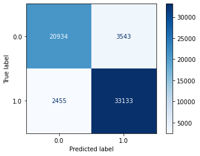

```python
best_clf = clf.best_estimator_
prediction = best_clf.predict(X_test)

accuracy = accuracy_score(y_test, prediction)
print(f"Accuracy: {accuracy}")

plot_confusion_matrix(best_clf, X_test, y_test, cmap=plt.cm.Blues)
```

We see that our model scores pretty decent on the testing data: a bit over 90%. However, as we saw in the beginning there was a slight inbalance in the trainingset: 60% of the set was positive (1.0) and 40% negative (0.0). For this reason we can make use of the f1-score. This metric uses precision and recall to assess a model.

```python
f1_score(y_test, prediction)
```

```
0.9169987822428871
```

If I am not mistaken, this is a pretty decent score!

## Questions

1. What does the ddof (degrees of freedom) argument of the std method of pandas indicate and why should it be 0?
2. In the f1-score the parameter 'average' a choice can be made between 'binary' (default), 'micro', 'macro', 'samples' and 'weighted'. Now I've read a thing or two about them, but I cant really make a decision whether to use one above the other. Does anyone know more about this or has a understandable source for me to use?

## Testing on the test-data

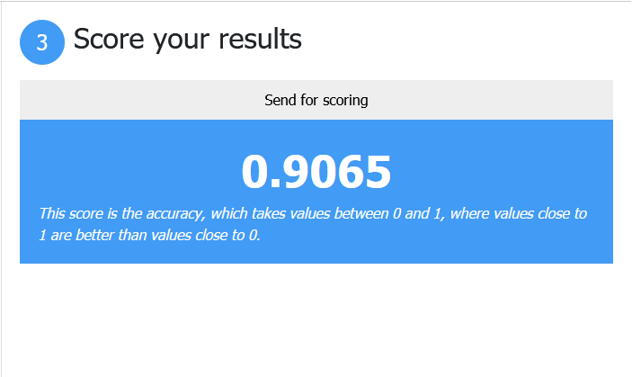